# Assignment 3: Regression

Ral Mogbogu

2025-12-10

```r
library(ggplot2) # Visualization
library(dplyr) # Data manipulation
library(caret)  # Predictive modeling
library(corrplot)
library(tidyr) # Data transformation
library(reshape2)
air <- read.csv("airquality.csv")
```

```r
View (air)
str(air)
```

```
## 'data.frame':    8991 obs. of  10 variables:
##  $ PT08.S1.CO.  : int  1360 1292 1402 1376 1272 1197 1185 1136 1094 1010 ...
##  $ NMHC.GT.     : int  150 112 88 80 51 38 31 31 24 19 ...
##  $ PT08.S2.NMHC.: int  1046 955 939 948 836 750 690 672 609 561 ...
##  $ NOx.GT.      : int  166 103 131 172 131 89 62 62 45 -200 ...
##  $ PT08.S3.NOx. : int  1056 1174 1140 1092 1205 1337 1462 1453 1579 1705 ...
##  $ NO2.GT.      : int  113 92 114 122 116 96 77 76 60 -200 ...
##  $ PT08.S4.NO2. : int  1692 1559 1555 1584 1490 1393 1333 1333 1276 1235 ...
##  $ PT08.S5.O3.  : int  1268 972 1074 1203 1110 949 733 730 620 501 ...
##  $ T            : int  136 133 119 110 112 112 113 107 107 103 ...
##  $ RH           : int  489 477 540 600 596 592 568 600 597 602 ...
```

```r
summary(air)
```

```
##   PT08.S1.CO.      NMHC.GT.      PT08.S2.NMHC.       NOx.GT.
##  Min.   : 647   Min.   :-200.0   Min.   : 383.0   Min.   :-200.0
##  1st Qu.: 937   1st Qu.:-200.0   1st Qu.: 734.5   1st Qu.:  49.0
##  Median :1063   Median :-200.0   Median : 909.0   Median : 140.0
##  Mean   :1100   Mean   :-158.7   Mean   : 939.2   Mean   : 163.7
##  3rd Qu.:1231   3rd Qu.:-200.0   3rd Qu.:1116.0   3rd Qu.: 280.0
##  Max.   :2040   Max.   :1189.0   Max.   :2214.0   Max.   :1479.0
##   PT08.S3.NOx.       NO2.GT.         PT08.S4.NO2.   PT08.S5.O3.
##  Min.   : 322.0   Min.   :-200.00   Min.   : 551   Min.   : 221.0
##  1st Qu.: 658.0   1st Qu.:  52.00   1st Qu.:1227   1st Qu.: 731.5
##  Median : 806.0   Median :  96.00   Median :1463   Median : 963.0
##  Mean   : 835.5   Mean   :  56.67   Mean   :1456   Mean   :1022.9
##  3rd Qu.: 969.5   3rd Qu.: 132.00   3rd Qu.:1674   3rd Qu.:1273.5
##  Max.   :2683.0   Max.   : 333.00   Max.   :2775   Max.   :2523.0
##        T               RH
##  Min.   :-19.0   Min.   : 92.0
##  1st Qu.:118.0   1st Qu.:358.0
##  Median :178.0   Median :496.0
##  Mean   :183.2   Mean   :492.3
##  3rd Qu.:244.0   3rd Qu.:625.0
##  Max.   :446.0   Max.   :887.0
```

```r
# filter missing data

apply(air,2,function(x) sum(is.na(x)))
```

```
##   PT08.S1.CO.      NMHC.GT. PT08.S2.NMHC.       NOx.GT.  PT08.S3.NOx.
##             0             0             0             0             0
##       NO2.GT.  PT08.S4.NO2.   PT08.S5.O3.             T            RH
##             0             0             0             0             0
```

```r
str(air)
```

```
## 'data.frame':    8991 obs. of  10 variables:
##  $ PT08.S1.CO.  : int  1360 1292 1402 1376 1272 1197 1185 1136 1094 1010 ...
##  $ NMHC.GT.     : int  150 112 88 80 51 38 31 31 24 19 ...
##  $ PT08.S2.NMHC.: int  1046 955 939 948 836 750 690 672 609 561 ...
##  $ NOx.GT.      : int  166 103 131 172 131 89 62 62 45 -200 ...
##  $ PT08.S3.NOx. : int  1056 1174 1140 1092 1205 1337 1462 1453 1579 1705 ...
##  $ NO2.GT.      : int  113 92 114 122 116 96 77 76 60 -200 ...
##  $ PT08.S4.NO2. : int  1692 1559 1555 1584 1490 1393 1333 1333 1276 1235 ...
##  $ PT08.S5.O3.  : int  1268 972 1074 1203 1110 949 733 730 620 501 ...
##  $ T            : int  136 133 119 110 112 112 113 107 107 103 ...
##  $ RH           : int  489 477 540 600 596 592 568 600 597 602 ...
```

## Part 1: Linear regression

```r
air_lm <- lm(RH ~.,
             data = air)
summary(air_lm)
```

```
##
## Call:
## lm(formula = RH ~ ., data = air)
##
## Residuals:
##     Min      1Q  Median      3Q     Max
## -260.63  -58.92  -10.01   51.64  654.78
##
## Coefficients:
##                 Estimate Std. Error  t value Pr(>|t|)
## (Intercept)   847.483979  13.679633   61.952  < 2e-16 ***
## PT08.S1.CO.     0.078204   0.012116    6.455 1.14e-10 ***
## NMHC.GT.       -0.151073   0.007683  -19.664  < 2e-16 ***
## PT08.S2.NMHC.  -0.911804   0.010913  -83.550  < 2e-16 ***
## NOx.GT.         0.369233   0.009312   39.653  < 2e-16 ***
## PT08.S3.NOx.   -0.266736   0.006568  -40.611  < 2e-16 ***
## NO2.GT.        -0.570866   0.014369  -39.730  < 2e-16 ***
## PT08.S4.NO2.    0.637352   0.005942  107.262  < 2e-16 ***
## PT08.S5.O3.     0.000229   0.006430    0.036    0.972
## T              -1.869471   0.016173 -115.593  < 2e-16 ***
## ---
## Signif. codes:  0 '***' 0.001 '**' 0.01 '*' 0.05 '.' 0.1 ' ' 1
##
## Residual standard error: 83.54 on 8981 degrees of freedom
## Multiple R-squared:  0.7675, Adjusted R-squared:  0.7673
## F-statistic:  3295 on 9 and 8981 DF,  p-value: < 2.2e-16
```

- Strong model; successful
- R-Squared for this linear model is 0.7675 suggests a strong fit, showing that 76.75% or ~77% of variance in RH (Relative Humidity %) is explained by a combination of factors attributed to air quality and temperature predictor variables.

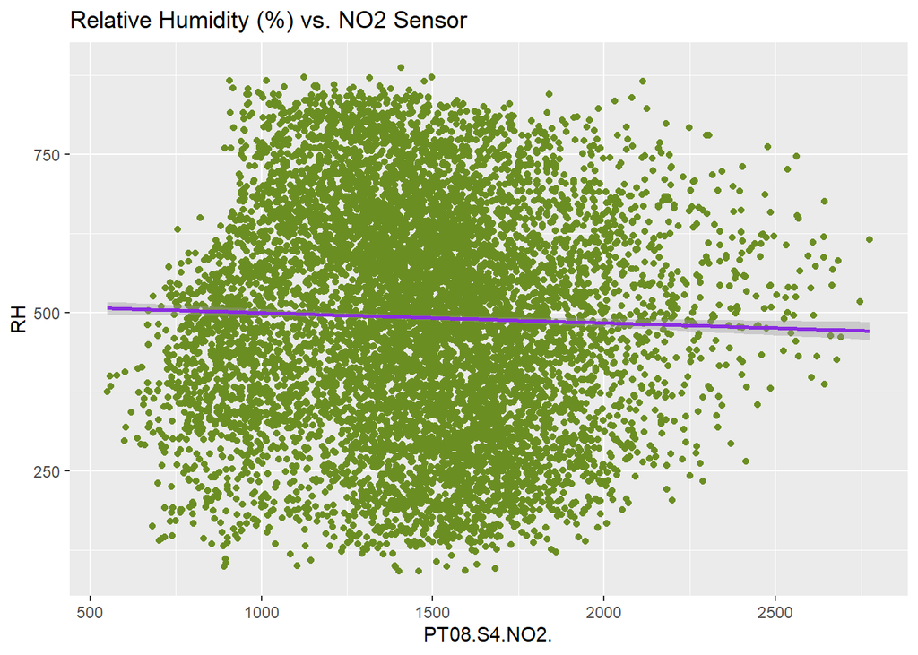

```r
# plots "PT08.S4.NO2." and "T"

ggplot(air, aes(x = PT08.S4.NO2., y = RH)) +
  geom_point(color = "olivedrab") +
  geom_smooth(method = "lm", color = "blueviolet") +
  labs(title = "Relative Humidity (%) vs. NO2 Sensor")
```

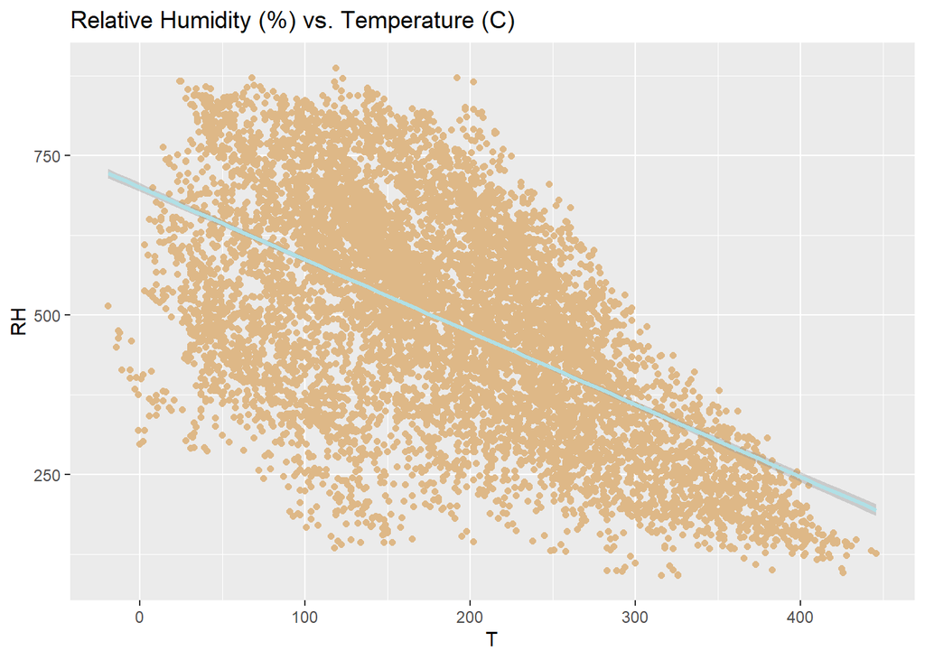

```r
ggplot(air, aes(x = T, y = RH)) +
  geom_point(color = "burlywood") +
  geom_smooth(method = "lm", color = "powderblue") +
  labs(title = "Relative Humidity (%) vs. Temperature (C)")
```

- Plot comparing Relative Humidity (%) vs. Temparature (RH vs. T) shows a strong negative relationship (-1.869471 @ P < 0.05), indicating that higher temparature readings correlate with a decrease in relative humidity.

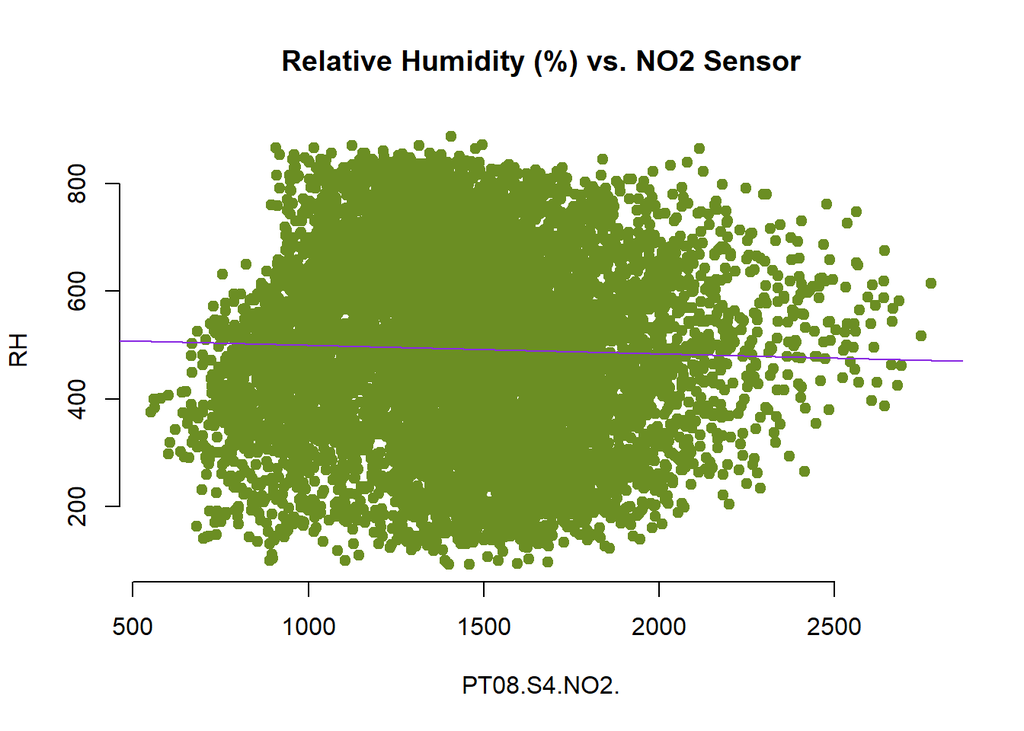

```r
### another way to plot (testing out different methods)
plot(air$PT08.S4.NO2., air$RH, main = "Relative Humidity (%) vs. NO2 Sensor",
     xlab = "PT08.S4.NO2.", ylab = "RH",
     pch = 19, frame = FALSE, col= "olivedrab")
abline(lm(RH~ PT08.S4.NO2., data = air), col = "blueviolet")
```

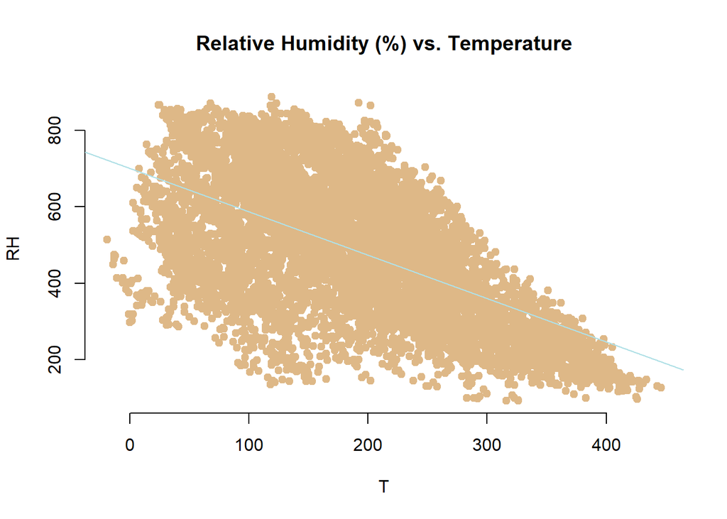

```r
plot(air$T, air$RH, main = "Relative Humidity (%) vs. Temperature",
     xlab = "T", ylab = "RH",
     pch = 19, frame = FALSE, col= "burlywood")
abline(lm(RH~ T, data = air), col = "powderblue")
```

## Part 2: Logistic Regression

convert the numerical variable to categorical: * RH< 492 RH_categorical=0 * RH=> 492 RH_categorical=1

```r
# numerical --> categorical
air_new <- air
air_new$RH_categorical <- as.factor(ifelse(air_new$RH < 492, 0, 1))
air_new <- subset(air_new, select = -RH)
##drop the column RH: new subset created without the RH column to be replaced with RH_categorical now; made a copy of the dataset so as to avoid affecting OG dataset in case I need to backtrack)
```

```r
str(air_new)
```

```
## 'data.frame':    8991 obs. of  10 variables:
##  $ PT08.S1.CO.   : int  1360 1292 1402 1376 1272 1197 1185 1136 1094 1010 ...
##  $ NMHC.GT.      : int  150 112 88 80 51 38 31 31 24 19 ...
##  $ PT08.S2.NMHC. : int  1046 955 939 948 836 750 690 672 609 561 ...
##  $ NOx.GT.       : int  166 103 131 172 131 89 62 62 45 -200 ...
##  $ PT08.S3.NOx.  : int  1056 1174 1140 1092 1205 1337 1462 1453 1579 1705 ...
##  $ NO2.GT.       : int  113 92 114 122 116 96 77 76 60 -200 ...
##  $ PT08.S4.NO2.  : int  1692 1559 1555 1584 1490 1393 1333 1333 1276 1235 ...
##  $ PT08.S5.O3.   : int  1268 972 1074 1203 1110 949 733 730 620 501 ...
##  $ T             : int  136 133 119 110 112 112 113 107 107 103 ...
##  $ RH_categorical: Factor w/ 2 levels "0","1": 1 1 2 2 2 2 2 2 2 2 ...
```

```r
View(air_new)
```

```r
air_logm <- glm(RH_categorical~., data = air_new, family = binomial)
summary(air_logm)
```

```
##
## Call:
## glm(formula = RH_categorical ~ ., family = binomial, data = air_new)
##
## Coefficients:
##                 Estimate Std. Error z value Pr(>|z|)
## (Intercept)    8.5208606  0.5937940  14.350  < 2e-16 ***
## PT08.S1.CO.    0.0020180  0.0004834   4.174 2.99e-05 ***
## NMHC.GT.      -0.0040444  0.0003232 -12.515  < 2e-16 ***
## PT08.S2.NMHC. -0.0255643  0.0006625 -38.586  < 2e-16 ***
## NOx.GT.        0.0112168  0.0004899  22.898  < 2e-16 ***
## PT08.S3.NOx.  -0.0071715  0.0003168 -22.640  < 2e-16 ***
## NO2.GT.       -0.0179789  0.0007466 -24.081  < 2e-16 ***
## PT08.S4.NO2.   0.0181930  0.0004387  41.468  < 2e-16 ***
## PT08.S5.O3.    0.0004218  0.0002643   1.596    0.111
## T             -0.0528008  0.0013047 -40.470  < 2e-16 ***
## ---
## Signif. codes:  0 '***' 0.001 '**' 0.01 '*' 0.05 '.' 0.1 ' ' 1
##
## (Dispersion parameter for binomial family taken to be 1)
##
##     Null deviance: 12461.7  on 8990  degrees of freedom
## Residual deviance:  5263.3  on 8981  degrees of freedom
## AIC: 5283.3
##
## Number of Fisher Scoring iterations: 7
```

- The logistic regression model for air quality shows strong predictive capability. With a low residual deviance as compared to the null deviance value (5263.3 vs. 12461.7) and P-values at < 2e-16 (P < 0.05) for most predictors, this indicates that air quality offers high predictions for relative humidity in the environment. In other words, air quality can be used to classify humidity. Specifically, PT08.S2.NMHC amd T shows in this model that they are the strongest in decreasing the odds of a high relative humidity.